# Background

Buying and selling used smartphones used to be something that happened on a handful of online marketplace sites. But the used and refurbished phone market has grown considerably over the past decade, and a new IDC (International Data Corporation) forecast predicts that the used phone market would be worth $52.7bn by 2023 with a compound annual growth rate (CAGR) of 13.6% from 2018 to 2023. This growth can be attributed to an uptick in demand for used smartphones that offer considerable savings compared with new models.

Refurbished and used devices continue to provide cost-effective alternatives to both consumers and businesses that are looking to save money when purchasing a smartphone. There are plenty of other benefits associated with the used smartphone market. Used and refurbished devices can be sold with warranties and can also be insured with proof of purchase. Third-party vendors/platforms, such as Verizon, Amazon, etc., provide attractive offers to customers for refurbished smartphones. Maximizing the longevity of mobile phones through second-hand trade also reduces their environmental impact and helps in recycling and reducing waste. The impact of the COVID-19 outbreak may further boost the cheaper refurbished smartphone segment, as consumers cut back on discretionary spending and buy phones only for immediate needs.

# Objective

The rising potential of this comparatively under-the-radar market fuels the need for an ML-based solution to develop a dynamic pricing strategy for used and refurbished smartphones. ReCell, a startup aiming to tap the potential in this market, has hired you as a data scientist. They want you to analyze the data provided and build a linear regression model to predict the price of a used phone and identify factors that significantly influence it.

# Data Dictionary

- brand_name: Name of manufacturing brand
- os: OS on which the phone runs
- screen_size: Size of the screen in cm
- 4g: Whether 4G is available or not
- 5g: Whether 5G is available or not
- main_camera_mp: Resolution of the rear camera in megapixels
- selfie_camera_mp: Resolution of the front camera in megapixels
- int_memory: Amount of internal memory (ROM) in GB
- ram: Amount of RAM in GB
- battery: Energy capacity of the phone battery in mAh
- weight: Weight of the phone in grams
- release_year: Year when the phone model was released
- days_used: Number of days the used/refurbished phone has been used
- new_price: Price of a new phone of the same model in euros
- used_price: Price of the used/refurbished phone in euros

# Importing necessary libraries and data

```python
# This will help in making the Python code more structured automatically (good coding practice)
%load_ext nb_black

import numpy as np
import pandas as pd
import matplotlib.pyplot as plt
import seaborn as sns

%matplotlib inline
# Automatically display graphs when created.
sns.set()
# Provides more contrast for easier graph viewing

import warnings

warnings.filterwarnings("ignore")
# hide warnings

from sklearn.model_selection import train_test_split

# Randomly split data into train/test sets
from sklearn.linear_model import LinearRegression

# Used to build linear regression model
from sklearn.metrics import mean_absolute_error, mean_squared_error, r2_score

# Used to check model performance

df = pd.read_csv("used_phone_data.csv")
phone = df.copy()
# Make a copy so that dataframe changed do not effect original data.
pd.set_option("display.max_columns", None)
# Removes the limit for the number of displayed columns
pd.set_option("display.max_rows", 200)
# Sets the limit for the number of displayed rows
```

# Data Overview

```python
# View 10 random rows, check if data imported correctly and how each series is formatted.
# Set np.random.seed so the same random results are produced with each method call.
np.random.seed(0)
phone.sample(n=10)
```

|  | brand_name | os | screen_size | 4g | 5g | main_camera_mp | selfie_camera_mp | int_memory | ram | battery | weight | release_year | days_used | new_price | used_price |
| --- | --- | --- | --- | --- | --- | --- | --- | --- | --- | --- | --- | --- | --- | --- | --- |
| 1014 | Celkon | Others | 6.03 | no | no | 1.3 | 0.3 | 256.0 | 0.25 | 3000.0 | 140.0 | 2013 | 787 | 29.510 | 11.96 |
| 2457 | Samsung | Android | 15.88 | yes | no | 12.0 | 25.0 | 128.0 | 4.00 | 4000.0 | 166.0 | 2019 | 377 | 350.210 | 225.92 |
| 1633 | Lenovo | Android | 17.78 | no | no | 2.0 | 0.3 | 32.0 | 4.00 | 3450.0 | 269.0 | 2015 | 585 | 98.860 | 49.77 |
| 117 | Nokia | Android | 28.10 | yes | yes | 0.3 | 24.0 | 64.0 | 6.00 | 4500.0 | 220.0 | 2020 | 284 | 501.120 | 341.09 |
| 2189 | Nokia | Windows | 10.95 | yes | no | 8.0 | 1.3 | 16.0 | 4.00 | 2000.0 | 139.0 | 2013 | 707 | 259.150 | 103.65 |
| 501 | Alcatel | Android | 13.02 | yes | no | 8.0 | 5.0 | 32.0 | 4.00 | 2800.0 | 159.5 | 2017 | 619 | 200.190 | 80.08 |
| 1939 | Micromax | Android | 12.70 | yes | no | 13.0 | 5.0 | 16.0 | 4.00 | 2260.0 | 143.0 | 2015 | 794 | 229.870 | 92.01 |
| 2090 | Motorola | Android | 13.02 | yes | no | 21.0 | 2.0 | 64.0 | 4.00 | 3900.0 | 176.0 | 2014 | 768 | 300.480 | 120.22 |
| 45 | Huawei | Android | 23.65 | yes | yes | 13.0 | 16.0 | 512.0 | 12.00 | 4500.0 | 198.0 | 2019 | 289 | 1699.360 | 1185.73 |
| 3528 | Realme | Android | 15.72 | yes | no | NaN | 16.0 | 64.0 | 4.00 | 4035.0 | 184.0 | 2019 | 433 | 159.885 | 80.00 |

```python
phone.info()
```

```
<class 'pandas.core.frame.DataFrame'>
RangeIndex: 3571 entries, 0 to 3570
Data columns (total 15 columns):
 #   Column            Non-Null Count  Dtype
---  ------            --------------  -----
 0   brand_name        3571 non-null   object
 1   os                3571 non-null   object
 2   screen_size       3571 non-null   float64
 3   4g                3571 non-null   object
 4   5g                3571 non-null   object
 5   main_camera_mp    3391 non-null   float64
 6   selfie_camera_mp  3569 non-null   float64
 7   int_memory        3561 non-null   float64
 8   ram               3561 non-null   float64
 9   battery           3565 non-null   float64
 10  weight            3564 non-null   float64
 11  release_year      3571 non-null   int64
 12  days_used         3571 non-null   int64
 13  new_price         3571 non-null   float64
 14  used_price        3571 non-null   float64
dtypes: float64(9), int64(2), object(4)
memory usage: 418.6+ KB
```

- 3571 rows, 15 series.
- All numeric series are either float/integer data types.
- Series present with null values that need to be addressed later.
- Object series will be converted to category data type for further analysis.

```python
# Number of null values in each series in descending order
phone.isnull().sum().sort_values(ascending=False)
```

```
main_camera_mp      180
int_memory           10
ram                  10
weight                7
battery               6
selfie_camera_mp      2
brand_name            0
os                    0
screen_size           0
4g                    0
5g                    0
release_year          0
days_used             0
new_price             0
used_price            0
dtype: int64
```

- Main camera resolution has the highest number of null values.
- Internal memory and ram share the same number of null values, possibly sharing the same rows.
- Weight, battery, and front camera resolution are the remaining null containing series.

```python
# View a statistical summary of the dataframe
phone.describe(include="all")
```

|  | brand_name | os | screen_size | 4g | 5g | main_camera_mp | selfie_camera_mp | int_memory | ram | battery | weight | release_year | days_used | new_price | used_price |
| --- | --- | --- | --- | --- | --- | --- | --- | --- | --- | --- | --- | --- | --- | --- | --- |
| count | 3571 | 3571 | 3571.000000 | 3571 | 3571 | 3391.000000 | 3569.000000 | 3561.000000 | 3561.000000 | 3565.000000 | 3564.000000 | 3571.000000 | 3571.000000 | 3571.000000 | 3571.000000 |
| unique | 34 | 4 | NaN | 2 | 2 | NaN | NaN | NaN | NaN | NaN | NaN | NaN | NaN | NaN | NaN |
| top | Others | Android | NaN | yes | no | NaN | NaN | NaN | NaN | NaN | NaN | NaN | NaN | NaN | NaN |
| freq | 509 | 3246 | NaN | 2359 | 3419 | NaN | NaN | NaN | NaN | NaN | NaN | NaN | NaN | NaN | NaN |
| mean | NaN | NaN | 14.803892 | NaN | NaN | 9.400454 | 6.547352 | 54.532607 | 4.056962 | 3067.225666 | 179.424285 | 2015.964996 | 675.391487 | 237.389037 | 109.880277 |
| std | NaN | NaN | 5.153092 | NaN | NaN | 4.818396 | 6.879359 | 84.696246 | 1.391844 | 1364.206665 | 90.280856 | 2.291784 | 248.640972 | 197.545581 | 121.501226 |
| min | NaN | NaN | 2.700000 | NaN | NaN | 0.080000 | 0.300000 | 0.005000 | 0.030000 | 80.000000 | 23.000000 | 2013.000000 | 91.000000 | 9.130000 | 2.510000 |
| 25% | NaN | NaN | 12.700000 | NaN | NaN | 5.000000 | 2.000000 | 16.000000 | 4.000000 | 2100.000000 | 140.000000 | 2014.000000 | 536.000000 | 120.130000 | 45.205000 |
| 50% | NaN | NaN | 13.490000 | NaN | NaN | 8.000000 | 5.000000 | 32.000000 | 4.000000 | 3000.000000 | 159.000000 | 2016.000000 | 690.000000 | 189.800000 | 75.530000 |
| 75% | NaN | NaN | 16.510000 | NaN | NaN | 13.000000 | 8.000000 | 64.000000 | 4.000000 | 4000.000000 | 184.000000 | 2018.000000 | 872.000000 | 291.935000 | 126.000000 |
| max | NaN | NaN | 46.360000 | NaN | NaN | 48.000000 | 32.000000 | 1024.000000 | 16.000000 | 12000.000000 | 950.000000 | 2020.000000 | 1094.000000 | 2560.200000 | 1916.540000 |

```python
phone.skew()
```

```
screen_size         0.858232
main_camera_mp      0.728767
selfie_camera_mp    1.823390
int_memory          5.744733
ram                 1.733612
battery             1.169535
weight              3.143147
release_year        0.319971
days_used          -0.341654
new_price           3.738930
used_price          4.749091
dtype: float64
```

## Categorical series

- Unnamed brand names make up under 15% of the sample.
- 4g phones make up over half of the samples while 5g phones are rare.

## Numerical series

- Range of screen size is extreme and could be due to typos(2 cm screen?) or incorrect classification (46cm=size of a large tablet).
- Selfie camera resolution significantly right skewed.
- Internal memory storage has large variance which is expected from tiered models. Significantly right skewed.
- 0.03 GB RAM for a phone seems unrealistic, could be typo.
- 80 mAh for battery power seems unrealistic (1000 mAh=1 hour charge).
- Phone weight in grams has extreme range, significantly right skewed. Needs further analysis.
- Days used has a large variance.
- Used price is significantly right skewed.

# Exploratory Data Analysis (Pre-Processing)

## Univariate Analysis

### Categorical variables

```python
# Create a class that adds a percentage on top of each variable for each countplot inserted.
def countPct(countPlot, seriesSum):
    total = len(seriesSum)  # Number of values in each series
    for column in ax.patches:
        """ax is short for axes, which are elements of a figure, or in this context subplots of a figure.
        A figure can contain multiple axes, but for our categorial variables we just have 1 ax which is the
        count plot. .patches is a class we can use to modify the axes space, in this case adding a percentage
        to the top of each variable column.
        """
        percentage = "{:.1f}%".format(
            100 * column.get_height() / total
        )  # .1f=1 decimal float.
        x = (
            column.get_x() + column.get_width() / 2 - 0.3
        )  # Assigning x and y as the grid location of the percentage element.
        y = column.get_y() + column.get_height()
        ax.annotate(
            percentage, (x, y)
        )  # final attribute to place each percentage at the defined location.
```

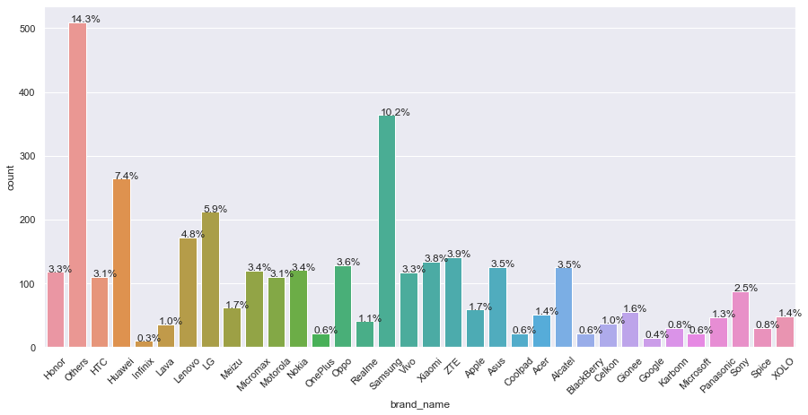

```python
plt.figure(figsize=(15, 7))
plt.xticks(rotation=45)
ax = sns.countplot(phone["brand_name"])
countPct(ax, phone["brand_name"])
```

34 different brands, Samsun has the highest count after unnamed brands.

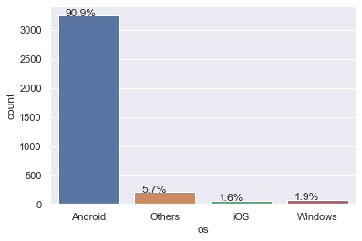

```python
ax = sns.countplot(phone["os"])
countPct(ax, phone["os"])
```

Android phones make up over 90% of the market based on the sample.

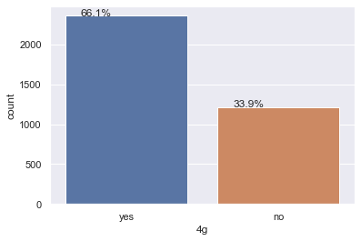

```python
ax = sns.countplot(phone["4g"])
countPct(ax, phone["4g"])
```

Two thirds of the sample has 4g access.

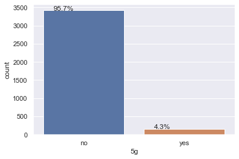

```python
ax = sns.countplot(phone["5g"])
countPct(ax, phone["5g"])
```

Less than 5% of phones in the sample have 5g access.

### Numerical Variables

```python
"""Create a function stacking a histogram and boxplots together
so that central tendency and dispersion can be visualized."""


def histogramBoxplot(series):
    # Creating a variable figure, which contains a defined number of axes, in this case 2 subplots
    figure, (axBox, axHist) = plt.subplots(
        nrows=2, sharex=True, gridspec_kw={"height_ratios": (0.25, 0.75)},
    )
    # Number of rows of the subplot grid=2
    # Share x axis label on all subplots
    sns.boxplot(
        series, ax=axBox, showmeans=True
    )  # showmeans visualizes mean of series.
    sns.distplot(
        series, ax=axHist, kde=False
    )  # kde=False turn kernal density estimate off,
    # Create two lines on histogram that show median and mean of series, matching color of boxplot.
    axHist.axvline(np.median(series), color="black")
    axHist.axvline(np.mean(series), color="green")
```

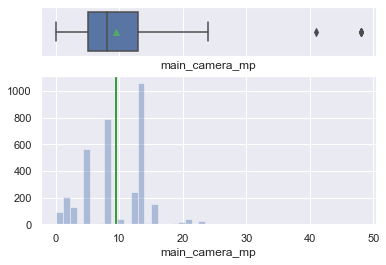

```python
histogramBoxplot(phone["main_camera_mp"])
```

Approximately normally distributed with a few outliers.

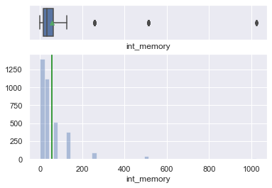

```python
histogramBoxplot(phone["int_memory"])
```

Extremely large outliers for internal memory storage.

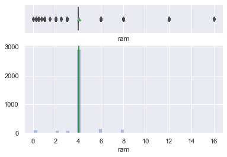

```python
histogramBoxplot(phone["ram"])
```

Ram has strong central tendency at 4GB.

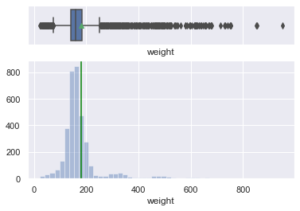

```python
histogramBoxplot(phone["weight"])
```

Weight has numerous large outliers.

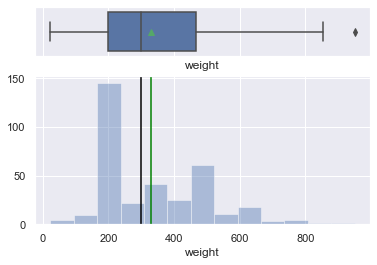

```python
weightBattery4500 = phone.loc[phone["battery"] > 4500, "weight"]
histogramBoxplot(weightBattery4500)
```

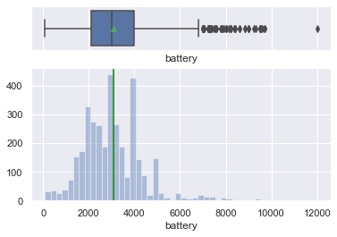

```python
histogramBoxplot(phone["battery"])
```

Approximately normally distributed but with numerous large outliers.

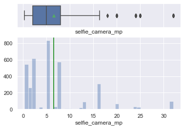

```python
histogramBoxplot(phone["selfie_camera_mp"])
```

Most selfie camera resolution is between 0-17 MP.

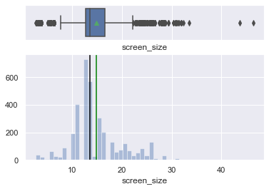

```python
histogramBoxplot(phone["screen_size"])
```

Approximately normally distributed with numorous small and large outliers.

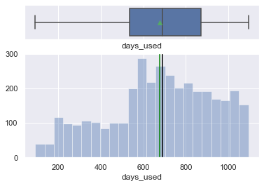

```python
histogramBoxplot(phone["days_used"])
```

Days phones are used before resale range from 91 to 1094.

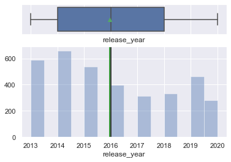

```python
histogramBoxplot(phone["release_year"])
```

Release years range from 2013 to 2020.

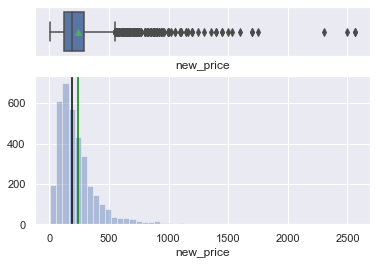

```python
histogramBoxplot(phone["new_price"])
```

New_price is significantly right skewed with numerous outliers.

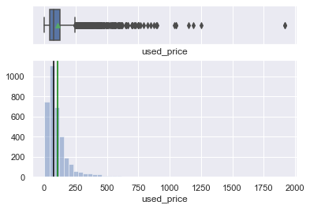

```python
histogramBoxplot(phone["used_price"])
```

Used_price reflects new_price distribution.

## Multivariate analysis

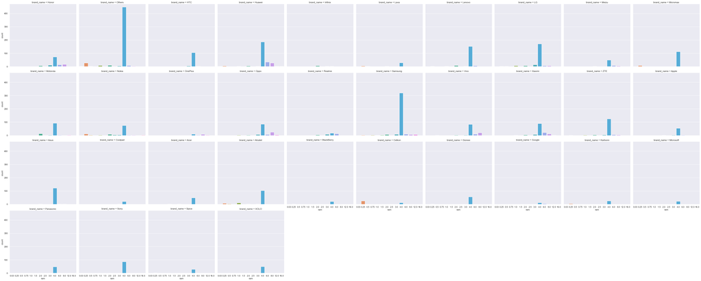

```python
sns.catplot(data=phone, x="ram", col="brand_name", kind="count", col_wrap=10)
```

Most brands sell with 4 GB ram storage suggesting that is the minimum needed for a fully functional phone.

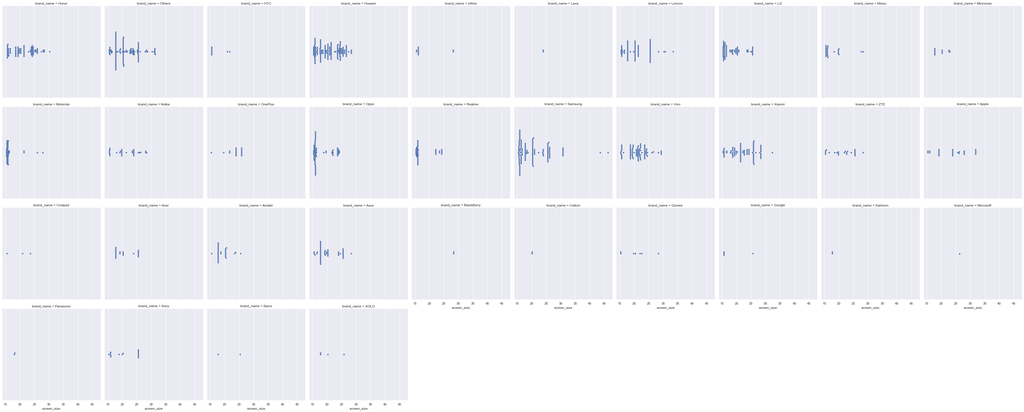

```python
sixInchesToCm = 6 * 2.54
brandScreen6 = phone.loc[phone["screen_size"] > sixInchesToCm]
sns.catplot(
    data=brandScreen6, x="screen_size", col="brand_name", kind="swarm", col_wrap=10
)
```

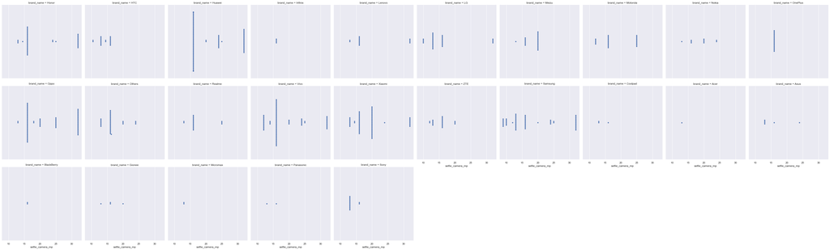

```python
brandSelfie8 = phone.loc[phone["selfie_camera_mp"] > 8]
sns.catplot(
    data=brandSelfie8, x="selfie_camera_mp", col="brand_name", kind="swarm", col_wrap=10
)
```

Having at least 15 megapixels is popular across brands (that carry models with >8 mp for the selfie camera) to provide quality selfie pictures for phone owners.

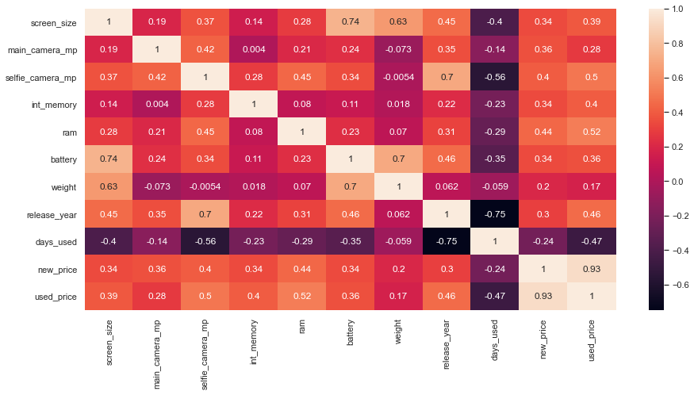

```python
phoneCorr = phone.corr()  # Create a correlation table variable for heatmap plot
plt.figure(figsize=(15, 7))
sns.heatmap(phoneCorr, annot=True)
# Heatmap will help visualize correlation easily.
# Annot will display correlation value.
# Correlation does not imply causation.
```

New price is highly positively correlated with used price, which is to be expected as used price is the depreciated market value of new price. Battery, weight, release_year, screen_size, selfie_camera_mp show moderate to high correlation, which may indicate multicollinearity. This will be confirmed later when the assumption is tested.

# Data Preprocessing

## Missing Value Treatment

```python
"""The median value for each series will be used to replace their respective null values.
A function will be used that will automatically apply the median value where needed.
"""
medianFiller = lambda x: x.fillna(x.median())
numeric_columns = df.select_dtypes(include=np.number).columns.tolist()
# create a list of all numeric columns in dataframe
phone[numeric_columns] = phone[numeric_columns].apply(medianFiller, axis=0)
# axis=0 means columnwise
```

```python
# Check the number of missing values.
phone.isnull().sum()
```

```
brand_name          0
os                  0
screen_size         0
4g                  0
5g                  0
main_camera_mp      0
selfie_camera_mp    0
int_memory          0
ram                 0
battery             0
weight              0
release_year        0
days_used           0
new_price           0
used_price          0
dtype: int64
```

All null values filled with their respective series median.

## Feature Engineering

```python
# Series with object data type need to be changed to catagorical data type.
cat_vars = ["brand_name", "os", "4g", "5g"]
for colname in cat_vars:
    df[colname] = df[colname].astype("category")
df.info()
```

```
<class 'pandas.core.frame.DataFrame'>
RangeIndex: 3571 entries, 0 to 3570
Data columns (total 15 columns):
 #   Column            Non-Null Count  Dtype
---  ------            --------------  -----
 0   brand_name        3571 non-null   category
 1   os                3571 non-null   category
 2   screen_size       3571 non-null   float64
 3   4g                3571 non-null   category
 4   5g                3571 non-null   category
 5   main_camera_mp    3391 non-null   float64
 6   selfie_camera_mp  3569 non-null   float64
 7   int_memory        3561 non-null   float64
 8   ram               3561 non-null   float64
 9   battery           3565 non-null   float64
 10  weight            3564 non-null   float64
 11  release_year      3571 non-null   int64
 12  days_used         3571 non-null   int64
 13  new_price         3571 non-null   float64
 14  used_price        3571 non-null   float64
dtypes: category(4), float64(9), int64(2)
memory usage: 322.7 KB
```

All object data types converted to category data types.

## Outlier Treatment

```python
# Treat outliers in the data by flooring and capping.
def treat_outliers(df, col):
    """
    treats outliers in a variable
    col: str, name of the numerical variable
    df: dataframe
    col: name of the column
    """
    Q1 = df[col].quantile(0.25)  # 25th quantile
    Q3 = df[col].quantile(0.75)  # 75th quantile
    IQR = Q3 - Q1
    Lower_Whisker = Q1 - 1.5 * IQR
    Upper_Whisker = Q3 + 1.5 * IQR

    # all the values smaller than Lower_Whisker will be assigned the value of Lower_Whisker
    # all the values greater than Upper_Whisker will be assigned the value of Upper_Whisker
    df[col] = np.clip(df[col], Lower_Whisker, Upper_Whisker)

    return df


def treat_outliers_all(df, col_list):
    """
    treat outlier in all numerical variables
    col_list: list of numerical variables
    df: data frame
    """
    for c in col_list:
        df = treat_outliers(df, c)

    return df
```

```python
numerical_col = df.select_dtypes(include=np.number).columns.tolist()
df = treat_outliers_all(df, numerical_col)
```

All outlier replaced with respective whisker values.

# Exploratory Data Analysis (Post processing)

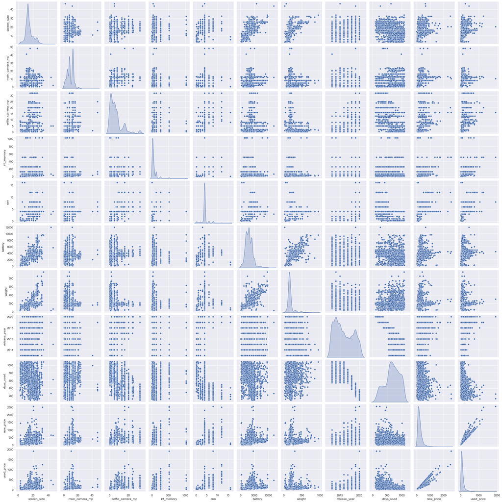

```python
sns.pairplot(
    phone, diag_kind="kde"
)  # to plot density curve instead of histogram on the diagram
```

Visually multicollinearity and linearity (exept for new_price) doesn't seem to hold true between the numeric predictor variables and used_price. These assumptions will be tested later when the regression model is built.

# Building a Linear Regression model

```python
# Before building a linear regression model, categorical variables need to be encoded.
phone = pd.get_dummies(phone, drop_first=True)
```

```python
# The objective is to predict used phone prices.
# independant (predictor) variables
X = phone.drop(["used_price"], axis=1)
# dependent (target/response) variable
y = phone[["used_price"]]
```

```python
# Split X and y into training and test sets in 70:30 ratio
# A linear regression model will be built on the training data and tested with the test data.
X_train, X_test, y_train, y_test = train_test_split(
    X, y, test_size=0.30, random_state=1
)
```

```python
# Intialize the model and fit it on the training data.
regression_model = LinearRegression()
regression_model.fit(X_train, y_train)
```

```
LinearRegression()
```

```python
# Checking coefficients and intercept.
coef_df = pd.DataFrame(
    np.append(regression_model.coef_, regression_model.intercept_),
    index=X_train.columns.tolist() + ["Intercept"],
    columns=["Coefficients"],
)

coef_df
```

|  | Coefficients |
| --- | --- |
| screen_size | -0.419229 |
| main_camera_mp | -1.837246 |
| selfie_camera_mp | -0.215874 |
| int_memory | 0.047554 |
| ram | 3.969076 |
| battery | 0.000059 |
| weight | -0.022810 |
| release_year | 2.977479 |
| days_used | -0.105978 |
| new_price | 0.532224 |
| brand_name_Alcatel | 3.875305 |
| brand_name_Apple | 165.270992 |
| brand_name_Asus | -3.590652 |
| brand_name_BlackBerry | -1.724121 |
| brand_name_Celkon | 12.690482 |
| brand_name_Coolpad | 2.204975 |
| brand_name_Gionee | -14.736668 |
| brand_name_Google | -12.744839 |
| brand_name_HTC | -4.231265 |
| brand_name_Honor | -6.917880 |
| brand_name_Huawei | -1.382407 |
| brand_name_Infinix | -13.183619 |
| brand_name_Karbonn | 8.231911 |
| brand_name_LG | -0.345744 |
| brand_name_Lava | 7.660234 |
| brand_name_Lenovo | -2.586004 |
| brand_name_Meizu | -4.306295 |
| brand_name_Micromax | 8.549361 |
| brand_name_Microsoft | 6.594759 |
| brand_name_Motorola | -1.785556 |
| brand_name_Nokia | -10.451041 |
| brand_name_OnePlus | -15.802806 |
| brand_name_Oppo | -12.946775 |
| brand_name_Others | -0.442489 |
| brand_name_Panasonic | 2.614053 |
| brand_name_Realme | -16.601219 |
| brand_name_Samsung | -5.332780 |
| brand_name_Sony | 4.381860 |
| brand_name_Spice | 13.001223 |
| brand_name_Vivo | -11.601681 |
| brand_name_XOLO | 8.562232 |
| brand_name_Xiaomi | -1.386160 |
| brand_name_ZTE | 4.674625 |
| os_Others | -0.888160 |
| os_Windows | -0.875195 |
| os_iOS | -203.234185 |
| 4g_yes | -6.880299 |
| 5g_yes | 52.516933 |
| Intercept | -5932.374929 |

- $R^2$=Coefficient of Determination
- $SSR$=Sum of squared due to regression
- $SSE$=Sum of squared errors
- $SST$=Sum of squared total
- $SST=SSE+SSR$
- $R^2=\frac{SSR}{SST}$

```python
def r_squared(model, X, y):
    y_mean = y.mean()
    SST = ((y - y_mean) ** 2).sum()
    SSE = ((y - model.predict(X)) ** 2).sum()
    r_square = 1 - SSE / SST
    return SSE, SST, r_square


SSE, SST, r_square = r_squared(regression_model, X_train, y_train)
print("SSE: ", SSE)
print("SST: ", SST)
print("R-squared: ", r_square)
```

```
SSE:  used_price    1.939213e+06
dtype: float64
SST:  used_price    3.784469e+07
dtype: float64
R-squared:  used_price    0.948759
dtype: float64
```

$R^2$ is high which indicates a high amount of the variability of used_price is captured by the predictor variables in the regression model.

# Checking Linear Regression Assumptions

```python
import statsmodels.api as sm

# unlike sklearn, statsmodels does not add a constant to the data on its own
# we have to add the constant manually
X_train = sm.add_constant(X_train)
# Add constant to test data
X_test = sm.add_constant(X_test)

olsmodel = sm.OLS(y_train, X_train).fit()
print(olsmodel.summary())
```

```
                            OLS Regression Results
==============================================================================
Dep. Variable:             used_price   R-squared:                       0.949
Model:                            OLS   Adj. R-squared:                  0.948
Method:                 Least Squares   F-statistic:                     945.1
Date:                Fri, 20 Aug 2021   Prob (F-statistic):               0.00
Time:                        16:49:25   Log-Likelihood:                -11860.
No. Observations:                2499   AIC:                         2.382e+04
Df Residuals:                    2450   BIC:                         2.410e+04
Df Model:                          48
Covariance Type:            nonrobust
=========================================================================================
                            coef    std err          t      P>|t|      [0.025      0.975]
-----------------------------------------------------------------------------------------
const                 -5932.3749   1035.323     -5.730      0.000   -7962.574   -3902.175
screen_size              -0.4192      0.197     -2.128      0.033      -0.806      -0.033
main_camera_mp           -1.8372      0.169    -10.856      0.000      -2.169      -1.505
selfie_camera_mp         -0.2159      0.135     -1.601      0.109      -0.480       0.048
int_memory                0.0476      0.008      5.973      0.000       0.032       0.063
ram                       3.9691      0.551      7.209      0.000       2.889       5.049
battery                5.875e-05      0.001      0.074      0.941      -0.001       0.002
weight                   -0.0228      0.011     -2.116      0.034      -0.044      -0.002
release_year              2.9775      0.513      5.799      0.000       1.971       3.984
days_used                -0.1060      0.004    -28.873      0.000      -0.113      -0.099
new_price                 0.5322      0.004    128.641      0.000       0.524       0.540
brand_name_Alcatel        3.8753      5.815      0.666      0.505      -7.527      15.278
brand_name_Apple        165.2710     21.105      7.831      0.000     123.885     206.657
brand_name_Asus          -3.5907      5.657     -0.635      0.526     -14.684       7.502
brand_name_BlackBerry    -1.7241      8.710     -0.198      0.843     -18.803      15.355
brand_name_Celkon        12.6905      7.782      1.631      0.103      -2.569      27.950
brand_name_Coolpad        2.2050      9.230      0.239      0.811     -15.895      20.305
brand_name_Gionee       -14.7367      6.559     -2.247      0.025     -27.599      -1.874
brand_name_Google       -12.7448     10.608     -1.201      0.230     -33.546       8.057
brand_name_HTC           -4.2313      5.781     -0.732      0.464     -15.567       7.105
brand_name_Honor         -6.9179      5.910     -1.171      0.242     -18.507       4.671
brand_name_Huawei        -1.3824      5.297     -0.261      0.794     -11.769       9.004
brand_name_Infinix      -13.1836     11.220     -1.175      0.240     -35.186       8.819
brand_name_Karbonn        8.2319      7.616      1.081      0.280      -6.702      23.166
brand_name_LG            -0.3457      5.366     -0.064      0.949     -10.868      10.176
brand_name_Lava           7.6602      7.537      1.016      0.310      -7.120      22.441
```

[output cut: 19 more lines]

```
os_Windows               -0.8752      5.400     -0.162      0.871     -11.465       9.715
os_iOS                 -203.2342     20.921     -9.714      0.000    -244.259    -162.210
4g_yes                   -6.8803      1.837     -3.745      0.000     -10.483      -3.277
5g_yes                   52.5169      3.738     14.048      0.000      45.186      59.847
==============================================================================
Omnibus:                     1813.612   Durbin-Watson:                   2.008
Prob(Omnibus):                  0.000   Jarque-Bera (JB):           291021.644
Skew:                           2.509   Prob(JB):                         0.00
Kurtosis:                      55.628   Cond. No.                     7.23e+06
==============================================================================

Notes:
[1] Standard Errors assume that the covariance matrix of the errors is correctly specified.
[2] The condition number is large, 7.23e+06. This might indicate that there are
strong multicollinearity or other numerical problems.
```

- Adjusted $R^2$ accounts for dimensionality (the number of predictor variables) and adjusts $R^2$ respectively.
- Adjusted $R^2$ is very close to $R^2$ indicating the high number of brand names did not effect $R^2$ too much.
- Constant coef=Y-intercept.
- This means if all the predictor variable coefficents are zero, the expected output (i.e., Y) would be equal to the constant coefficient. This value cannot be interpreted all the time.
- coef of predictor variables represents change in output Y due to a change in predictor variable (everything else held constant).
- std err reflects the level of accuracy of the coefficients.
- lower=higher level of accuracy.
- P>|t|=p-value.
- For each predictor variable, there is a null hypothesis and an alternate hypothesis. Here βi is the coefficient of the ith independent variable.
- $H_0$ : predictor variable is not significant (βi=0)
- $H_A$ : predictor variable is significant (βi≠0)
- P-value for each predictor variable used to check that null hypothesis.
- 0.05 (5%) is the significance level.
- Confidence Interval represents the range in which coefficients are likely to fall (with a likelihood of 95%).

## Test for Multicollinearity

- Multicollinearity is when predictor variables in a regression model are correlated, which indicates they are not independent.
- Variance Inflation Factor (VIF): Measures inflation in the variances of the regression parameter estimates due to collinearities that exist among the predictor variables.
- It is a measure of how much the variance of the estimated regression coefficient βk is "inflated" by the existence of correlation among the predictor variables in the model.
- If VIF is 1, then there is no correlation among the kth predictor and the remaining predictor variables, and hence, the variance of βk is not inflated at all.
- General Rule of thumb:
- If VIF is between 1 and 5, then there is low multicollinearity.
- If VIF is between 5 and 10, we say there is moderate multicollinearity.
- If VIF is exceeding 10, it shows signs of high multicollinearity.

```python
from statsmodels.stats.outliers_influence import variance_inflation_factor

# Define a function to check VIF
def checking_vif(predictors):
    vif = pd.DataFrame()
    vif["feature"] = predictors.columns

    # Calculating VIF for each feature
    vif["VIF"] = [
        variance_inflation_factor(predictors.values, i)
        for i in range(len(predictors.columns))
    ]
    return vif
```

```python
checking_vif(X_train)
```

|  | feature | VIF |
| --- | --- | --- |
| 0 | const | 3.384222e+06 |
| 1 | screen_size | 3.311469e+00 |
| 2 | main_camera_mp | 1.937682e+00 |
| 3 | selfie_camera_mp | 2.758291e+00 |
| 4 | int_memory | 1.381781e+00 |
| 5 | ram | 1.787815e+00 |
| 6 | battery | 3.703211e+00 |
| 7 | weight | 3.098083e+00 |
| 8 | release_year | 4.395322e+00 |
| 9 | days_used | 2.646152e+00 |
| 10 | new_price | 2.137805e+00 |
| 11 | brand_name_Alcatel | 3.107716e+00 |
| 12 | brand_name_Apple | 2.323850e+01 |
| 13 | brand_name_Asus | 3.470167e+00 |
| 14 | brand_name_BlackBerry | 1.523586e+00 |
| 15 | brand_name_Celkon | 1.818518e+00 |
| 16 | brand_name_Coolpad | 1.391965e+00 |
| 17 | brand_name_Gionee | 2.139588e+00 |
| 18 | brand_name_Google | 1.274912e+00 |
| 19 | brand_name_HTC | 3.269643e+00 |
| 20 | brand_name_Honor | 3.334512e+00 |
| 21 | brand_name_Huawei | 6.072276e+00 |
| 22 | brand_name_Infinix | 1.268388e+00 |
| 23 | brand_name_Karbonn | 1.669915e+00 |
| 24 | brand_name_LG | 5.096808e+00 |
| 25 | brand_name_Lava | 1.706139e+00 |
| 26 | brand_name_Lenovo | 4.259146e+00 |
| 27 | brand_name_Meizu | 2.256518e+00 |
| 28 | brand_name_Micromax | 3.227980e+00 |
| 29 | brand_name_Microsoft | 1.857679e+00 |
| 30 | brand_name_Motorola | 3.098817e+00 |
| 31 | brand_name_Nokia | 3.605957e+00 |
| 32 | brand_name_OnePlus | 1.617425e+00 |
| 33 | brand_name_Oppo | 3.886821e+00 |
| 34 | brand_name_Others | 9.561014e+00 |
| 35 | brand_name_Panasonic | 1.956567e+00 |
| 36 | brand_name_Realme | 1.925910e+00 |
| 37 | brand_name_Samsung | 7.848107e+00 |
| 38 | brand_name_Sony | 2.846803e+00 |
| 39 | brand_name_Spice | 1.750483e+00 |
| 40 | brand_name_Vivo | 3.464294e+00 |
| 41 | brand_name_XOLO | 2.015180e+00 |
| 42 | brand_name_Xiaomi | 4.023173e+00 |
| 43 | brand_name_ZTE | 3.658696e+00 |
| 44 | os_Others | 1.574330e+00 |
| 45 | os_Windows | 1.592727e+00 |
| 46 | os_iOS | 2.176468e+01 |
| 47 | 4g_yes | 2.379646e+00 |
| 48 | 5g_yes | 1.743567e+00 |

```python
X_train1 = X_train.drop(["battery"], axis=1)
X_test1 = X_test.drop(["battery"], axis=1)
```

```python
olsmod1 = sm.OLS(y_train, X_train1).fit()
print(olsmod1.summary())
```

```
                            OLS Regression Results
==============================================================================
Dep. Variable:             used_price   R-squared:                       0.949
Model:                            OLS   Adj. R-squared:                  0.948
Method:                 Least Squares   F-statistic:                     965.6
Date:                Fri, 20 Aug 2021   Prob (F-statistic):               0.00
Time:                        16:49:25   Log-Likelihood:                -11860.
No. Observations:                2499   AIC:                         2.382e+04
Df Residuals:                    2451   BIC:                         2.410e+04
Df Model:                          47
Covariance Type:            nonrobust
=========================================================================================
                            coef    std err          t      P>|t|      [0.025      0.975]
-----------------------------------------------------------------------------------------
const                 -5943.4992   1024.288     -5.803      0.000   -7952.059   -3934.939
screen_size              -0.4152      0.189     -2.194      0.028      -0.786      -0.044
main_camera_mp           -1.8364      0.169    -10.877      0.000      -2.167      -1.505
selfie_camera_mp         -0.2157      0.135     -1.601      0.110      -0.480       0.049
int_memory                0.0476      0.008      5.977      0.000       0.032       0.063
ram                       3.9696      0.550      7.212      0.000       2.890       5.049
weight                   -0.0224      0.009     -2.470      0.014      -0.040      -0.005
release_year              2.9830      0.508      5.873      0.000       1.987       3.979
days_used                -0.1060      0.004    -28.901      0.000      -0.113      -0.099
new_price                 0.5322      0.004    128.726      0.000       0.524       0.540
brand_name_Alcatel        3.8563      5.808      0.664      0.507      -7.533      15.245
brand_name_Apple        165.2806     21.101      7.833      0.000     123.904     206.657
brand_name_Asus          -3.5877      5.656     -0.634      0.526     -14.678       7.503
brand_name_BlackBerry    -1.7234      8.708     -0.198      0.843     -18.799      15.352
brand_name_Celkon        12.6801      7.779      1.630      0.103      -2.574      27.934
brand_name_Coolpad        2.2012      9.228      0.239      0.811     -15.894      20.297
brand_name_Gionee       -14.7172      6.553     -2.246      0.025     -27.567      -1.867
brand_name_Google       -12.7327     10.605     -1.201      0.230     -33.528       8.062
brand_name_HTC           -4.2396      5.779     -0.734      0.463     -15.571       7.092
brand_name_Honor         -6.9271      5.907     -1.173      0.241     -18.511       4.657
brand_name_Huawei        -1.3870      5.295     -0.262      0.793     -11.771       8.997
brand_name_Infinix      -13.1306     11.196     -1.173      0.241     -35.084       8.823
brand_name_Karbonn        8.2204      7.613      1.080      0.280      -6.708      23.149
brand_name_LG            -0.3457      5.365     -0.064      0.949     -10.866      10.174
brand_name_Lava           7.6643      7.536      1.017      0.309      -7.113      22.441
brand_name_Lenovo        -2.5772      5.452     -0.473      0.636     -13.267       8.113
```

[output cut: 18 more lines]

```
os_Windows               -0.8942      5.393     -0.166      0.868     -11.470       9.682
os_iOS                 -203.2649     20.913     -9.720      0.000    -244.273    -162.257
4g_yes                   -6.8558      1.807     -3.793      0.000     -10.400      -3.312
5g_yes                   52.5080      3.736     14.056      0.000      45.183      59.833
==============================================================================
Omnibus:                     1813.249   Durbin-Watson:                   2.008
Prob(Omnibus):                  0.000   Jarque-Bera (JB):           290838.750
Skew:                           2.508   Prob(JB):                         0.00
Kurtosis:                      55.612   Cond. No.                     3.91e+06
==============================================================================

Notes:
[1] Standard Errors assume that the covariance matrix of the errors is correctly specified.
[2] The condition number is large, 3.91e+06. This might indicate that there are
strong multicollinearity or other numerical problems.
```

```python
X_train2 = X_train1.drop(["selfie_camera_mp"], axis=1)
X_test2 = X_test1.drop(["selfie_camera_mp"], axis=1)
```

```python
olsmod2 = sm.OLS(y_train, X_train2).fit()
print(olsmod2.summary())
```

```
                            OLS Regression Results
==============================================================================
Dep. Variable:             used_price   R-squared:                       0.949
Model:                            OLS   Adj. R-squared:                  0.948
Method:                 Least Squares   F-statistic:                     985.9
Date:                Fri, 20 Aug 2021   Prob (F-statistic):               0.00
Time:                        16:49:25   Log-Likelihood:                -11862.
No. Observations:                2499   AIC:                         2.382e+04
Df Residuals:                    2452   BIC:                         2.409e+04
Df Model:                          46
Covariance Type:            nonrobust
=========================================================================================
                            coef    std err          t      P>|t|      [0.025      0.975]
-----------------------------------------------------------------------------------------
const                 -5390.5842    964.585     -5.589      0.000   -7282.069   -3499.099
screen_size              -0.4292      0.189     -2.270      0.023      -0.800      -0.058
main_camera_mp           -1.8810      0.167    -11.292      0.000      -2.208      -1.554
int_memory                0.0460      0.008      5.824      0.000       0.031       0.062
ram                       3.7800      0.538      7.030      0.000       2.726       4.834
weight                   -0.0213      0.009     -2.356      0.019      -0.039      -0.004
release_year              2.7087      0.478      5.663      0.000       1.771       3.647
days_used                -0.1056      0.004    -28.849      0.000      -0.113      -0.098
new_price                 0.5317      0.004    129.034      0.000       0.524       0.540
brand_name_Alcatel        3.9781      5.809      0.685      0.494      -7.414      15.370
brand_name_Apple        167.3295     21.068      7.942      0.000     126.016     208.643
brand_name_Asus          -3.4212      5.657     -0.605      0.545     -14.513       7.671
brand_name_BlackBerry    -1.8117      8.710     -0.208      0.835     -18.892      15.269
brand_name_Celkon        12.4361      7.780      1.598      0.110      -2.820      27.692
brand_name_Coolpad        2.0523      9.231      0.222      0.824     -16.048      20.153
brand_name_Gionee       -14.8494      6.554     -2.266      0.024     -27.702      -1.996
brand_name_Google       -12.2721     10.604     -1.157      0.247     -33.066       8.522
brand_name_HTC           -4.3714      5.780     -0.756      0.450     -15.706       6.963
brand_name_Honor         -7.1635      5.908     -1.213      0.225     -18.748       4.421
brand_name_Huawei        -1.7133      5.293     -0.324      0.746     -12.093       8.666
brand_name_Infinix      -13.4341     11.197     -1.200      0.230     -35.392       8.523
brand_name_Karbonn        8.0089      7.614      1.052      0.293      -6.922      22.940
brand_name_LG            -0.2950      5.366     -0.055      0.956     -10.818      10.228
brand_name_Lava           7.6905      7.538      1.020      0.308      -7.091      22.472
brand_name_Lenovo        -2.5640      5.453     -0.470      0.638     -13.258       8.130
brand_name_Meizu         -4.7676      6.571     -0.726      0.468     -17.652       8.117
```

[output cut: 17 more lines]

```
os_Windows               -0.6978      5.394     -0.129      0.897     -11.274       9.879
os_iOS                 -204.6903     20.900     -9.794      0.000    -245.674    -163.706
4g_yes                   -6.8839      1.808     -3.808      0.000     -10.429      -3.339
5g_yes                   52.2562      3.733     13.997      0.000      44.935      59.577
==============================================================================
Omnibus:                     1842.207   Durbin-Watson:                   2.007
Prob(Omnibus):                  0.000   Jarque-Bera (JB):           301186.052
Skew:                           2.572   Prob(JB):                         0.00
Kurtosis:                      56.536   Cond. No.                     3.68e+06
==============================================================================

Notes:
[1] Standard Errors assume that the covariance matrix of the errors is correctly specified.
[2] The condition number is large, 3.68e+06. This might indicate that there are
strong multicollinearity or other numerical problems.
```

```python
X_train3 = X_train2.drop(
    [
        "brand_name_Alcatel",
        "brand_name_Asus",
        "brand_name_BlackBerry",
        "brand_name_Celkon",
        "brand_name_Coolpad",
        "brand_name_Google",
        "brand_name_HTC",
        "brand_name_Honor",
        "brand_name_Huawei",
        "brand_name_Infinix",
        "brand_name_Karbonn",
        "brand_name_LG",
        "brand_name_Lava",
        "brand_name_Lenovo",
        "brand_name_Meizu",
        "brand_name_Micromax",
        "brand_name_Microsoft",
        "brand_name_Motorola",
        "brand_name_Nokia",
        "brand_name_OnePlus",
        "brand_name_Others",
        "brand_name_Panasonic",
        "brand_name_Samsung",
        "brand_name_Sony",
        "brand_name_Spice",
        "brand_name_XOLO",
        "brand_name_Xiaomi",
        "brand_name_ZTE",
    ],
    axis=1,
)
X_test3 = X_test2.drop(
    [
        "brand_name_Alcatel",
        "brand_name_Asus",
        "brand_name_BlackBerry",
        "brand_name_Celkon",
        "brand_name_Coolpad",
        "brand_name_Google",
        "brand_name_HTC",
        "brand_name_Honor",
        "brand_name_Huawei",
        "brand_name_Infinix",
        "brand_name_Karbonn",
        "brand_name_LG",
        "brand_name_Lava",
        "brand_name_Lenovo",
        "brand_name_Meizu",
        "brand_name_Micromax",
        "brand_name_Microsoft",
        "brand_name_Motorola",
        "brand_name_Nokia",
        "brand_name_OnePlus",
        "brand_name_Others",
        "brand_name_Panasonic",
        "brand_name_Samsung",
        "brand_name_Sony",
        "brand_name_Spice",
        "brand_name_XOLO",
        "brand_name_Xiaomi",
        "brand_name_ZTE",
    ],
    axis=1,
)
```

```python
olsmod3 = sm.OLS(y_train, X_train3).fit()
print(olsmod3.summary())
```

```
                            OLS Regression Results
==============================================================================
Dep. Variable:             used_price   R-squared:                       0.947
Model:                            OLS   Adj. R-squared:                  0.947
Method:                 Least Squares   F-statistic:                     2485.
Date:                Fri, 20 Aug 2021   Prob (F-statistic):               0.00
Time:                        16:49:25   Log-Likelihood:                -11892.
No. Observations:                2499   AIC:                         2.382e+04
Df Residuals:                    2480   BIC:                         2.393e+04
Df Model:                          18
Covariance Type:            nonrobust
=====================================================================================
                        coef    std err          t      P>|t|      [0.025      0.975]
-------------------------------------------------------------------------------------
const             -4732.0493    941.491     -5.026      0.000   -6578.239   -2885.860
screen_size          -0.5172      0.183     -2.822      0.005      -0.877      -0.158
main_camera_mp       -1.8354      0.159    -11.534      0.000      -2.147      -1.523
int_memory            0.0517      0.008      6.746      0.000       0.037       0.067
ram                   3.5312      0.529      6.671      0.000       2.493       4.569
weight               -0.0219      0.009     -2.479      0.013      -0.039      -0.005
release_year          2.3832      0.467      5.105      0.000       1.468       3.299
days_used            -0.1049      0.004    -28.896      0.000      -0.112      -0.098
new_price             0.5281      0.004    132.860      0.000       0.520       0.536
brand_name_Apple    178.3266     20.556      8.675      0.000     138.018     218.635
brand_name_Gionee   -14.6652      4.543     -3.228      0.001     -23.573      -5.757
brand_name_Oppo     -12.1589      3.008     -4.043      0.000     -18.056      -6.261
brand_name_Realme   -13.6999      5.434     -2.521      0.012     -24.356      -3.044
brand_name_Vivo      -9.8548      3.278     -3.006      0.003     -16.283      -3.427
os_Others            -4.9992      2.856     -1.751      0.080     -10.599       0.600
os_Windows           -1.3006      4.344     -0.299      0.765      -9.819       7.217
os_iOS             -212.7997     20.966    -10.150      0.000    -253.913    -171.687
4g_yes               -8.7797      1.726     -5.088      0.000     -12.164      -5.396
5g_yes               54.1890      3.727     14.539      0.000      46.880      61.498
==============================================================================
Omnibus:                     1876.344   Durbin-Watson:                   2.002
Prob(Omnibus):                  0.000   Jarque-Bera (JB):           307030.543
Skew:                           2.655   Prob(JB):                         0.00
Kurtosis:                      57.041   Cond. No.                     3.57e+06
==============================================================================

Notes:
[1] Standard Errors assume that the covariance matrix of the errors is correctly specified.
[2] The condition number is large, 3.57e+06. This might indicate that there are
strong multicollinearity or other numerical problems.
```

```python
X_train4 = X_train3.drop("os_Windows", axis=1)
X_test4 = X_test3.drop("os_Windows", axis=1)
```

```python
olsmod4 = sm.OLS(y_train, X_train4).fit()
print(olsmod4.summary())
```

```
                            OLS Regression Results
==============================================================================
Dep. Variable:             used_price   R-squared:                       0.947
Model:                            OLS   Adj. R-squared:                  0.947
Method:                 Least Squares   F-statistic:                     2632.
Date:                Fri, 20 Aug 2021   Prob (F-statistic):               0.00
Time:                        16:49:25   Log-Likelihood:                -11892.
No. Observations:                2499   AIC:                         2.382e+04
Df Residuals:                    2481   BIC:                         2.392e+04
Df Model:                          17
Covariance Type:            nonrobust
=====================================================================================
                        coef    std err          t      P>|t|      [0.025      0.975]
-------------------------------------------------------------------------------------
const             -4750.1036    939.385     -5.057      0.000   -6592.164   -2908.043
screen_size          -0.5166      0.183     -2.819      0.005      -0.876      -0.157
main_camera_mp       -1.8359      0.159    -11.540      0.000      -2.148      -1.524
int_memory            0.0518      0.008      6.751      0.000       0.037       0.067
ram                   3.5279      0.529      6.668      0.000       2.490       4.565
weight               -0.0218      0.009     -2.474      0.013      -0.039      -0.005
release_year          2.3921      0.466      5.136      0.000       1.479       3.305
days_used            -0.1049      0.004    -28.900      0.000      -0.112      -0.098
new_price             0.5281      0.004    132.887      0.000       0.520       0.536
brand_name_Apple    178.2573     20.551      8.674      0.000     137.959     218.555
brand_name_Gionee   -14.6273      4.540     -3.222      0.001     -23.530      -5.725
brand_name_Oppo     -12.1390      3.006     -4.038      0.000     -18.034      -6.244
brand_name_Realme   -13.7025      5.433     -2.522      0.012     -24.357      -3.048
brand_name_Vivo      -9.8419      3.277     -3.003      0.003     -16.268      -3.416
os_Others            -4.9621      2.852     -1.740      0.082     -10.555       0.631
os_iOS             -212.7120     20.960    -10.148      0.000    -253.814    -171.610
4g_yes               -8.7827      1.725     -5.090      0.000     -12.166      -5.399
5g_yes               54.1826      3.727     14.540      0.000      46.875      61.490
==============================================================================
Omnibus:                     1876.134   Durbin-Watson:                   2.002
Prob(Omnibus):                  0.000   Jarque-Bera (JB):           306888.163
Skew:                           2.654   Prob(JB):                         0.00
Kurtosis:                      57.029   Cond. No.                     3.56e+06
==============================================================================

Notes:
[1] Standard Errors assume that the covariance matrix of the errors is correctly specified.
[2] The condition number is large, 3.56e+06. This might indicate that there are
strong multicollinearity or other numerical problems.
```

```python
X_train5 = X_train4.drop("os_Others", axis=1)
X_test5 = X_test4.drop("os_Others", axis=1)
```

```python
olsmod5 = sm.OLS(y_train, X_train5).fit()
print(olsmod5.summary())
```

```
                            OLS Regression Results
==============================================================================
Dep. Variable:             used_price   R-squared:                       0.947
Model:                            OLS   Adj. R-squared:                  0.947
Method:                 Least Squares   F-statistic:                     2794.
Date:                Fri, 20 Aug 2021   Prob (F-statistic):               0.00
Time:                        16:49:25   Log-Likelihood:                -11893.
No. Observations:                2499   AIC:                         2.382e+04
Df Residuals:                    2482   BIC:                         2.392e+04
Df Model:                          16
Covariance Type:            nonrobust
=====================================================================================
                        coef    std err          t      P>|t|      [0.025      0.975]
-------------------------------------------------------------------------------------
const             -4570.2950    934.063     -4.893      0.000   -6401.919   -2738.672
screen_size          -0.4258      0.176     -2.423      0.015      -0.770      -0.081
main_camera_mp       -1.7883      0.157    -11.406      0.000      -2.096      -1.481
int_memory            0.0513      0.008      6.694      0.000       0.036       0.066
ram                   3.6409      0.525      6.931      0.000       2.611       4.671
weight               -0.0225      0.009     -2.554      0.011      -0.040      -0.005
release_year          2.3016      0.463      4.971      0.000       1.394       3.210
days_used            -0.1046      0.004    -28.841      0.000      -0.112      -0.097
new_price             0.5280      0.004    132.821      0.000       0.520       0.536
brand_name_Apple    172.5874     20.299      8.502      0.000     132.783     212.392
brand_name_Gionee   -14.3042      4.538     -3.152      0.002     -23.203      -5.405
brand_name_Oppo     -11.8944      3.004     -3.959      0.000     -17.785      -6.003
brand_name_Realme   -13.3000      5.431     -2.449      0.014     -23.949      -2.651
brand_name_Vivo     -10.0142      3.277     -3.056      0.002     -16.440      -3.588
os_iOS             -206.7705     20.689     -9.994      0.000    -247.339    -166.202
4g_yes               -8.4961      1.718     -4.945      0.000     -11.865      -5.127
5g_yes               53.8630      3.724     14.466      0.000      46.562      61.165
==============================================================================
Omnibus:                     1874.326   Durbin-Watson:                   2.000
Prob(Omnibus):                  0.000   Jarque-Bera (JB):           307338.219
Skew:                           2.649   Prob(JB):                         0.00
Kurtosis:                      57.070   Cond. No.                     3.54e+06
==============================================================================

Notes:
[1] Standard Errors assume that the covariance matrix of the errors is correctly specified.
[2] The condition number is large, 3.54e+06. This might indicate that there are
strong multicollinearity or other numerical problems.
```

All statistically insignificant predictor variables have been removed and $R^2$/adjusted $R^2$ is about the same.

## Test for Linearity and Independence

- Predictor variables must have a linear relation with the target variable.
- The independence of residuals need to be confirmed, otherwise confidence intervals of the coefficient estimates will be narrower and incorrectly conclude a predictor variable to be statistically significant.
- Linearity and independence checked with plot of fitted values vs residuals.
- No pattern=linear and residuals are independent.
- Otherwise, plot shows signs of non-linearity and residuals are not independent.

```python
# Create a dataframe with actual, fitted and residual values
df_pred = pd.DataFrame(index=np.arange(2499))
df_pred["Actual Values"] = y_train  # actual values
df_pred["Fitted Values"] = olsmod5.fittedvalues  # predicted values
df_pred["Residuals"] = olsmod5.resid  # residuals
df_pred.dropna(inplace=True)
df_pred.head()
```

|  | Actual Values | Fitted Values | Residuals |
| --- | --- | --- | --- |
| 0 | 86.96 | 93.528384 | -6.568384 |
| 1 | 161.49 | 217.641503 | -56.151503 |
| 2 | 268.55 | 294.437220 | -25.887220 |
| 5 | 113.67 | 111.862488 | 1.807512 |
| 8 | 150.88 | 154.096449 | -3.216449 |

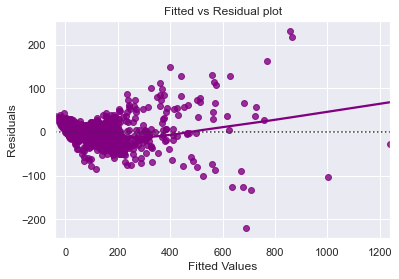

```python
# let's plot the fitted values vs residuals

sns.residplot(
    data=df_pred, x="Fitted Values", y="Residuals", color="purple", lowess=True
)
plt.xlabel("Fitted Values")
plt.ylabel("Residuals")
plt.title("Fitted vs Residual plot")
plt.show()
```

## Test for Normality

- Residuals should be normally distributed.
- If not, confidence intervals of the coefficient estimates may become too wide or narrow.
- Once confidence interval becomes unstable, it leads to difficulty in estimating coefficients based on minimization of least squares.
- The shape of the histogram of residuals can give an initial idea about the normality.
- It can also be checked via a Q-Q plot of residuals.
- If the residuals follow a normal distribution, they will make a straight line plot, otherwise not.
- Other tests to check for normality includes the Shapiro-Wilk test.
- Null hypothesis: Residuals are normally distributed
- Alternate hypothesis: Residuals are not normally distributed

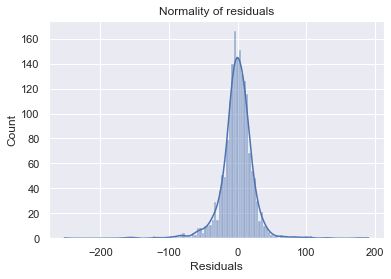

```python
sns.histplot(data=df_pred, x="Residuals", kde=True)
plt.title("Normality of residuals")
plt.show()
```

Residuals have a bell shaped curve.

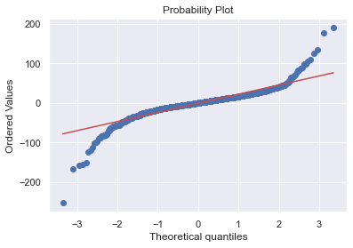

```python
# Q-Q plot
import pylab
import scipy.stats as stats

stats.probplot(df_pred["Residuals"], dist="norm", plot=pylab)
plt.show()
```

```python
stats.shapiro(df_pred["Residuals"])
```

```
ShapiroResult(statistic=0.8486031293869019, pvalue=8.874747154774018e-38)
```

Rejecting the shapiro null hypothesis technically means the residuals do not follow normal distribution, but using them as an approximation, our assumption can be satisfied.

## Test for Homoscedasticity

- Homoscedascity: If the variance of the residuals is symmetrically distributed across the regression line, then the data is said to be homoscedastic, otherwise it is heteroscedascity.
- The presence of non-constant variance in the error terms results in heteroscedasticity. Generally, non-constant variance arises in presence of outliers.
- The goldfeldquandt test can also be used. If we get a p-value > 0.05 we can say that the residuals are homoscedastic. Otherwise, they are heteroscedastic.
- Null hypothesis: Residuals are homoscedastic
- Alternate hypothesis: Residuals have heteroscedasticity

```python
# With outliers removed, residual vs fitted values plot holds no discernable pattern.
# Goldfeldquant will be used to confirm homoscedasticity.
import statsmodels.stats.api as sms
from statsmodels.compat import lzip

name = ["F statistic", "p-value"]
test = sms.het_goldfeldquandt(df_pred["Residuals"], X_train5.sample(1727))
lzip(name, test)
```

```
[('F statistic', 0.6025390330386655), ('p-value', 0.9999999999998856)]
```

Null hypothesis holds true, residuals are homoscedastic.

# Model performance evaluation

```python
pred_test = pd.DataFrame(index=np.arange(1072))
pred_test["Actual"] = y_test
pred_test["Predicted"] = olsmod5.predict(X_test5)
pred_test.dropna(inplace=True)
pred_test.sample(10)
```

|  | Actual | Predicted |
| --- | --- | --- |
| 1004 | 15.19 | -4.073350 |
| 457 | 38.77 | 17.141784 |
| 874 | 85.05 | 69.404382 |
| 494 | 39.40 | 51.564376 |
| 1050 | 19.99 | 39.188238 |
| 219 | 40.18 | 45.643884 |
| 955 | 56.57 | 53.963274 |
| 720 | 100.21 | 119.105010 |
| 1041 | 74.75 | 75.114892 |
| 756 | 99.15 | 88.914772 |

Predicted values generally matched actual values, indicating model performed okay.

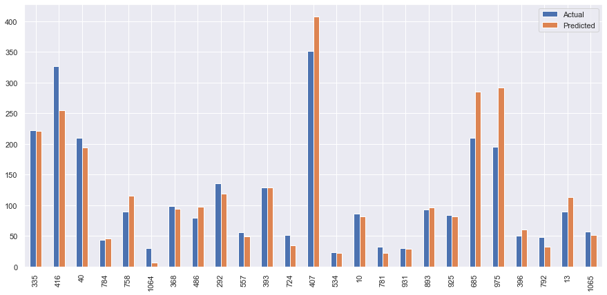

```python
df1 = pred_test.sample(25, random_state=1)
df1.plot(kind="bar", figsize=(15, 7))
plt.show()
```

# Final Model Summary

```python
olsmodel_final = sm.OLS(y_train, X_train5).fit()
print(olsmodel_final.summary())
```

```
                            OLS Regression Results
==============================================================================
Dep. Variable:             used_price   R-squared:                       0.947
Model:                            OLS   Adj. R-squared:                  0.947
Method:                 Least Squares   F-statistic:                     2794.
Date:                Fri, 20 Aug 2021   Prob (F-statistic):               0.00
Time:                        16:49:27   Log-Likelihood:                -11893.
No. Observations:                2499   AIC:                         2.382e+04
Df Residuals:                    2482   BIC:                         2.392e+04
Df Model:                          16
Covariance Type:            nonrobust
=====================================================================================
                        coef    std err          t      P>|t|      [0.025      0.975]
-------------------------------------------------------------------------------------
const             -4570.2950    934.063     -4.893      0.000   -6401.919   -2738.672
screen_size          -0.4258      0.176     -2.423      0.015      -0.770      -0.081
main_camera_mp       -1.7883      0.157    -11.406      0.000      -2.096      -1.481
int_memory            0.0513      0.008      6.694      0.000       0.036       0.066
ram                   3.6409      0.525      6.931      0.000       2.611       4.671
weight               -0.0225      0.009     -2.554      0.011      -0.040      -0.005
release_year          2.3016      0.463      4.971      0.000       1.394       3.210
days_used            -0.1046      0.004    -28.841      0.000      -0.112      -0.097
new_price             0.5280      0.004    132.821      0.000       0.520       0.536
brand_name_Apple    172.5874     20.299      8.502      0.000     132.783     212.392
brand_name_Gionee   -14.3042      4.538     -3.152      0.002     -23.203      -5.405
brand_name_Oppo     -11.8944      3.004     -3.959      0.000     -17.785      -6.003
brand_name_Realme   -13.3000      5.431     -2.449      0.014     -23.949      -2.651
brand_name_Vivo     -10.0142      3.277     -3.056      0.002     -16.440      -3.588
os_iOS             -206.7705     20.689     -9.994      0.000    -247.339    -166.202
4g_yes               -8.4961      1.718     -4.945      0.000     -11.865      -5.127
5g_yes               53.8630      3.724     14.466      0.000      46.562      61.165
==============================================================================
Omnibus:                     1874.326   Durbin-Watson:                   2.000
Prob(Omnibus):                  0.000   Jarque-Bera (JB):           307338.219
Skew:                           2.649   Prob(JB):                         0.00
Kurtosis:                      57.070   Cond. No.                     3.54e+06
==============================================================================

Notes:
[1] Standard Errors assume that the covariance matrix of the errors is correctly specified.
[2] The condition number is large, 3.54e+06. This might indicate that there are
strong multicollinearity or other numerical problems.
```

- An increase in screen size and/or weight of a phone decreases used phone price.
- Negative coefficient for main camera megapixels indicate they're not an important feature in higher used phone pricing.
- Internal memory and even more so RAM have high impact on used phone price.
- Release year and days used have positive/negative coefficients respectively which make sense as newer/less used phones will price higher.
- Apple used prices are over 172 euros higher than comparable brands in the sample.
- Gionee, Oppo, Realme, and Vivo used phones priced ~10-14 euros lower than comparable brands in the sample.
- Used phones with iOS operating systems priced ~206 euros lower than other operating systems in sample.
- 4g used phones priced ~8 euros lower than non 4g used phones, while 5g used phones priced ~53 euros higher than non 5g used phones.

# Actionable Insights and Recommendations

- Screen size, weight, and battery are highly correlated, as phone mass increases to accomodate each of these features. Screen size and weight decrease used phone price as the phone become too cumbersome to use as handheld devices.
- Main camera megapixels become less important in higher used phone pricing, while most selfie phone megapixels are at least 15 in >8 MP models. This would indicate higher selfie camera MP should be a focused feature of high end used phone reselling.
- Most phone models carry at least 4GB of RAM and increases in RAM size increase used phone price. This indicates 4GB RAM is the minimum needed for a fully functioning phone, with larger RAM sizes beneficial for higher end phones (such as for gaming).
- Apple phones can sell at a higher price point in their market share, but iOS phones price lower than competing operating systems such as Android makes up over 90% of the used phone market.
- Gionee, Oppo, Realme, and Vivo are all Chinese cellphone manufacturers that compete in a large domestic market with international brands like Huawai. Decrease in profit margin on resale value can be reflective of intense competition in these markets.
- With 5G networks steadily growing globally, having access to 5G phones is reflected in used phone pricing, especially in proportion to the decrease of 4g phone resale price.